# Risk Factor Analysis

## Outcome Variable

**Outcome Variable:** stunted

## Predictor Variables

**Intervention Variable:** month

**Adjustment Set:**

unadjusted

## Stratifying Variables

The analysis was stratified on these variable(s):

- agecat
- studyid

The following strata were considered:

- agecat: 12 months, studyid: ki0047075b-MAL-ED
- agecat: 12 months, studyid: ki1000108-CMC-V-BCS-2002
- agecat: 12 months, studyid: ki1000108-IRC
- agecat: 12 months, studyid: ki1000109-EE
- agecat: 12 months, studyid: ki1000109-ResPak
- agecat: 12 months, studyid: ki1000304b-SAS-FoodSuppl
- agecat: 12 months, studyid: ki1017093-NIH-Birth
- agecat: 12 months, studyid: ki1066203-TanzaniaChild2
- agecat: 12 months, studyid: ki1112895-Guatemala BSC
- agecat: 12 months, studyid: ki1113344-GMS-Nepal
- agecat: 12 months, studyid: ki1114097-CMIN
- agecat: 12 months, studyid: ki1114097-CONTENT
- agecat: 12 months, studyid: ki1126311-ZVITAMBO
- agecat: 12 months, studyid: ki1148112-LCNI-5
- agecat: 18 months, studyid: ki0047075b-MAL-ED
- agecat: 18 months, studyid: ki1000108-CMC-V-BCS-2002
- agecat: 18 months, studyid: ki1000108-IRC
- agecat: 18 months, studyid: ki1000109-EE
- agecat: 18 months, studyid: ki1000109-ResPak
- agecat: 18 months, studyid: ki1000304b-SAS-FoodSuppl
- agecat: 18 months, studyid: ki1017093-NIH-Birth
- agecat: 18 months, studyid: ki1066203-TanzaniaChild2
- agecat: 18 months, studyid: ki1113344-GMS-Nepal
- agecat: 18 months, studyid: ki1114097-CMIN
- agecat: 18 months, studyid: ki1114097-CONTENT
- agecat: 18 months, studyid: ki1126311-ZVITAMBO
- agecat: 18 months, studyid: ki1148112-LCNI-5
- agecat: 24 months, studyid: ki0047075b-MAL-ED
- agecat: 24 months, studyid: ki1000108-CMC-V-BCS-2002
- agecat: 24 months, studyid: ki1000108-IRC
- agecat: 24 months, studyid: ki1017093-NIH-Birth
- agecat: 24 months, studyid: ki1066203-TanzaniaChild2
- agecat: 24 months, studyid: ki1113344-GMS-Nepal
- agecat: 24 months, studyid: ki1114097-CMIN
- agecat: 24 months, studyid: ki1114097-CONTENT
- agecat: 24 months, studyid: ki1126311-ZVITAMBO
- agecat: 24 months, studyid: ki1148112-LCNI-5
- agecat: 3 months, studyid: ki0047075b-MAL-ED
- agecat: 3 months, studyid: ki1000108-CMC-V-BCS-2002
- agecat: 3 months, studyid: ki1000108-IRC
- agecat: 3 months, studyid: ki1000109-EE
- agecat: 3 months, studyid: ki1000109-ResPak
- agecat: 3 months, studyid: ki1000304b-SAS-FoodSuppl
- agecat: 3 months, studyid: ki1017093-NIH-Birth
- agecat: 3 months, studyid: ki1066203-TanzaniaChild2
- agecat: 3 months, studyid: ki1112895-Guatemala BSC
- agecat: 3 months, studyid: ki1113344-GMS-Nepal
- agecat: 3 months, studyid: ki1114097-CMIN
- agecat: 3 months, studyid: ki1114097-CONTENT
- agecat: 3 months, studyid: ki1126311-ZVITAMBO
- agecat: 6 months, studyid: ki0047075b-MAL-ED
- agecat: 6 months, studyid: ki1000108-CMC-V-BCS-2002
- agecat: 6 months, studyid: ki1000108-IRC
- agecat: 6 months, studyid: ki1000109-EE
- agecat: 6 months, studyid: ki1000109-ResPak
- agecat: 6 months, studyid: ki1000304b-SAS-FoodSuppl
- agecat: 6 months, studyid: ki1017093-NIH-Birth
- agecat: 6 months, studyid: ki1066203-TanzaniaChild2
- agecat: 6 months, studyid: ki1112895-Guatemala BSC
- agecat: 6 months, studyid: ki1113344-GMS-Nepal
- agecat: 6 months, studyid: ki1114097-CMIN
- agecat: 6 months, studyid: ki1114097-CONTENT
- agecat: 6 months, studyid: ki1126311-ZVITAMBO
- agecat: 6 months, studyid: ki1148112-LCNI-5
- agecat: 9 months, studyid: ki0047075b-MAL-ED
- agecat: 9 months, studyid: ki1000108-CMC-V-BCS-2002
- agecat: 9 months, studyid: ki1000108-IRC
- agecat: 9 months, studyid: ki1000109-EE
- agecat: 9 months, studyid: ki1000109-ResPak
- agecat: 9 months, studyid: ki1000304b-SAS-FoodSuppl
- agecat: 9 months, studyid: ki1017093-NIH-Birth
- agecat: 9 months, studyid: ki1066203-TanzaniaChild2
- agecat: 9 months, studyid: ki1112895-Guatemala BSC
- agecat: 9 months, studyid: ki1113344-GMS-Nepal
- agecat: 9 months, studyid: ki1114097-CMIN
- agecat: 9 months, studyid: ki1114097-CONTENT
- agecat: 9 months, studyid: ki1126311-ZVITAMBO
- agecat: 9 months, studyid: ki1148112-LCNI-5
- agecat: Birth, studyid: ki0047075b-MAL-ED
- agecat: Birth, studyid: ki1000108-CMC-V-BCS-2002
- agecat: Birth, studyid: ki1000108-IRC
- agecat: Birth, studyid: ki1000109-EE
- agecat: Birth, studyid: ki1000109-ResPak
- agecat: Birth, studyid: ki1017093-NIH-Birth
- agecat: Birth, studyid: ki1114097-CMIN
- agecat: Birth, studyid: ki1114097-CONTENT
- agecat: Birth, studyid: ki1126311-ZVITAMBO

### Dropped Strata

Some strata were dropped due to rare outcomes:

- agecat: Birth, studyid: ki1000108-CMC-V-BCS-2002
- agecat: Birth, studyid: ki1000108-IRC
- agecat: Birth, studyid: ki1000109-EE
- agecat: Birth, studyid: ki1000109-ResPak
- agecat: Birth, studyid: ki1017093-NIH-Birth
- agecat: Birth, studyid: ki1114097-CMIN
- agecat: Birth, studyid: ki1114097-CONTENT
- agecat: 3 months, studyid: ki1000108-CMC-V-BCS-2002
- agecat: 3 months, studyid: ki1000108-IRC
- agecat: 3 months, studyid: ki1000109-EE
- agecat: 3 months, studyid: ki1000109-ResPak
- agecat: 3 months, studyid: ki1000304b-SAS-FoodSuppl
- agecat: 3 months, studyid: ki1066203-TanzaniaChild2
- agecat: 3 months, studyid: ki1112895-Guatemala BSC
- agecat: 3 months, studyid: ki1113344-GMS-Nepal
- agecat: 3 months, studyid: ki1114097-CONTENT
- agecat: 6 months, studyid: ki1000109-EE
- agecat: 6 months, studyid: ki1000109-ResPak
- agecat: 6 months, studyid: ki1000304b-SAS-FoodSuppl
- agecat: 6 months, studyid: ki1066203-TanzaniaChild2
- agecat: 6 months, studyid: ki1112895-Guatemala BSC
- agecat: 6 months, studyid: ki1113344-GMS-Nepal
- agecat: 6 months, studyid: ki1114097-CONTENT
- agecat: 6 months, studyid: ki1148112-LCNI-5
- agecat: 9 months, studyid: ki1000108-CMC-V-BCS-2002
- agecat: 9 months, studyid: ki1000109-EE
- agecat: 9 months, studyid: ki1000109-ResPak
- agecat: 9 months, studyid: ki1000304b-SAS-FoodSuppl
- agecat: 9 months, studyid: ki1066203-TanzaniaChild2
- agecat: 9 months, studyid: ki1112895-Guatemala BSC
- agecat: 9 months, studyid: ki1113344-GMS-Nepal
- agecat: 9 months, studyid: ki1114097-CONTENT
- agecat: 9 months, studyid: ki1148112-LCNI-5
- agecat: 12 months, studyid: ki1000108-CMC-V-BCS-2002
- agecat: 12 months, studyid: ki1000109-EE
- agecat: 12 months, studyid: ki1000109-ResPak
- agecat: 12 months, studyid: ki1000304b-SAS-FoodSuppl
- agecat: 12 months, studyid: ki1066203-TanzaniaChild2
- agecat: 12 months, studyid: ki1112895-Guatemala BSC
- agecat: 12 months, studyid: ki1113344-GMS-Nepal
- agecat: 12 months, studyid: ki1114097-CONTENT
- agecat: 12 months, studyid: ki1148112-LCNI-5
- agecat: 18 months, studyid: ki1000108-CMC-V-BCS-2002
- agecat: 18 months, studyid: ki1000109-EE
- agecat: 18 months, studyid: ki1000109-ResPak
- agecat: 18 months, studyid: ki1000304b-SAS-FoodSuppl
- agecat: 18 months, studyid: ki1066203-TanzaniaChild2
- agecat: 18 months, studyid: ki1113344-GMS-Nepal
- agecat: 18 months, studyid: ki1114097-CONTENT
- agecat: 18 months, studyid: ki1148112-LCNI-5
- agecat: 24 months, studyid: ki1000108-CMC-V-BCS-2002
- agecat: 24 months, studyid: ki1000108-IRC
- agecat: 24 months, studyid: ki1066203-TanzaniaChild2
- agecat: 24 months, studyid: ki1113344-GMS-Nepal
- agecat: 24 months, studyid: ki1114097-CONTENT
- agecat: 24 months, studyid: ki1126311-ZVITAMBO
- agecat: 24 months, studyid: ki1148112-LCNI-5

## Methods Detail

We’re interested in the causal parameters $E[Y_a]$ for all values of $a \in \mathcal{A}$. These parameters represent the mean outcome if, possibly contrary to fact, we intervened to set all units to have $A=a$. Under the randomization and positivity assumptions, these are identified by the statistical parameters $\psi_a=E_W[E_{Y|A,W}(Y|A=a,W)]$. In addition, we’re interested in the mean of $Y$, $E[Y]$ under no intervention (the observed mean). We will estimate these parameters by using SuperLearner to fit the relevant likelihood factors – $E_{Y|A,W}(Y|A=a,W)$ and $p(A=a|W)$, and then updating our likelihood fit using a joint TMLE.

For unadjusted analyses ($W=\{\}$), initial likelihoods were estimated using Lrnr_glm to estimate the simple $E(Y|A)$ and Lrnr_mean to estimate $p(A)$. For adjusted analyses, a small library containing Lrnr_glmnet, Lrnr_xgboost, and Lrnr_mean was used.

Having estimated these parameters, we will then use the delta method to estimate relative risks and attributable risks relative to a prespecified baseline level of $A$.

# Results Detail

## Results Plots

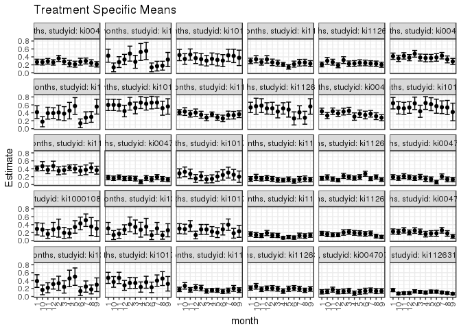

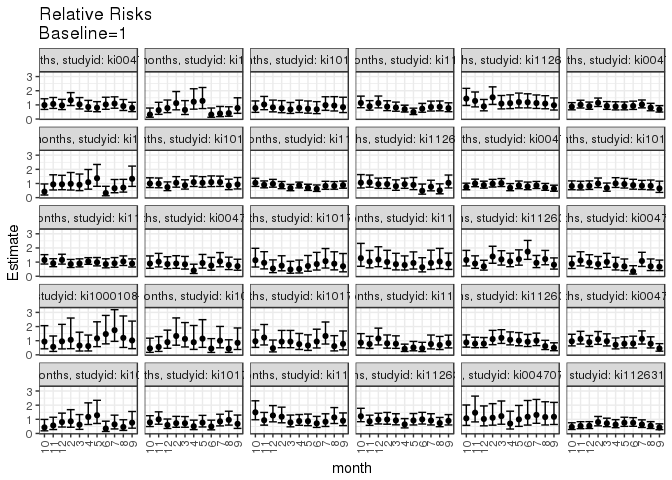

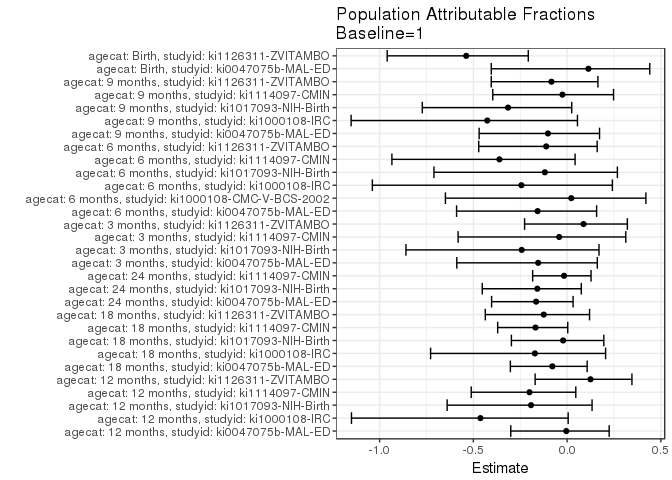

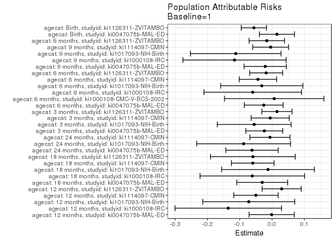

## Data Summary

| agecat | studyid | A | n | nA | nAY0 | nAY1 |
| --- | --- | --- | --- | --- | --- | --- |
| Birth | ki0047075b-MAL-ED | 1 | 1499 | 136 | 120 | 16 |
| Birth | ki0047075b-MAL-ED | 2 | 1499 | 130 | 113 | 17 |
| Birth | ki0047075b-MAL-ED | 3 | 1499 | 125 | 107 | 18 |
| Birth | ki0047075b-MAL-ED | 4 | 1499 | 97 | 89 | 8 |
| Birth | ki0047075b-MAL-ED | 5 | 1499 | 111 | 98 | 13 |
| Birth | ki0047075b-MAL-ED | 6 | 1499 | 94 | 81 | 13 |
| Birth | ki0047075b-MAL-ED | 7 | 1499 | 136 | 115 | 21 |
| Birth | ki0047075b-MAL-ED | 8 | 1499 | 110 | 95 | 15 |
| Birth | ki0047075b-MAL-ED | 9 | 1499 | 137 | 118 | 19 |
| Birth | ki0047075b-MAL-ED | 10 | 1499 | 143 | 125 | 18 |
| Birth | ki0047075b-MAL-ED | 11 | 1499 | 139 | 115 | 24 |
| Birth | ki0047075b-MAL-ED | 12 | 1499 | 141 | 124 | 17 |
| Birth | ki1000108-CMC-V-BCS-2002 | 1 | 90 | 9 | 7 | 2 |
| Birth | ki1000108-CMC-V-BCS-2002 | 2 | 90 | 1 | 0 | 1 |
| Birth | ki1000108-CMC-V-BCS-2002 | 3 | 90 | 8 | 7 | 1 |
| Birth | ki1000108-CMC-V-BCS-2002 | 4 | 90 | 9 | 7 | 2 |
| Birth | ki1000108-CMC-V-BCS-2002 | 5 | 90 | 11 | 10 | 1 |
| Birth | ki1000108-CMC-V-BCS-2002 | 6 | 90 | 9 | 8 | 1 |
| Birth | ki1000108-CMC-V-BCS-2002 | 7 | 90 | 7 | 7 | 0 |
| Birth | ki1000108-CMC-V-BCS-2002 | 8 | 90 | 4 | 3 | 1 |
| Birth | ki1000108-CMC-V-BCS-2002 | 9 | 90 | 7 | 5 | 2 |
| Birth | ki1000108-CMC-V-BCS-2002 | 10 | 90 | 10 | 8 | 2 |
| Birth | ki1000108-CMC-V-BCS-2002 | 11 | 90 | 11 | 10 | 1 |
| Birth | ki1000108-CMC-V-BCS-2002 | 12 | 90 | 4 | 2 | 2 |
| Birth | ki1000108-IRC | 1 | 388 | 34 | 27 | 7 |
| Birth | ki1000108-IRC | 2 | 388 | 25 | 23 | 2 |
| Birth | ki1000108-IRC | 3 | 388 | 27 | 23 | 4 |
| Birth | ki1000108-IRC | 4 | 388 | 22 | 20 | 2 |
| Birth | ki1000108-IRC | 5 | 388 | 21 | 20 | 1 |
| Birth | ki1000108-IRC | 6 | 388 | 34 | 30 | 4 |

[output cut: 1146 more lines]

## Results Table

### Parameter: TSM

| agecat | studyid | intervention_level | baseline_level | estimate | ci_lower | ci_upper |
| --- | --- | --- | --- | --- | --- | --- |
| Birth | ki0047075b-MAL-ED | 1 | NA | 0.1176471 | 0.0634800 | 0.1718141 |
| Birth | ki0047075b-MAL-ED | 2 | NA | 0.1307692 | 0.0727941 | 0.1887444 |
| Birth | ki0047075b-MAL-ED | 3 | NA | 0.1440000 | 0.0824318 | 0.2055682 |
| Birth | ki0047075b-MAL-ED | 4 | NA | 0.0824743 | 0.0277128 | 0.1372358 |
| Birth | ki0047075b-MAL-ED | 5 | NA | 0.1171171 | 0.0572769 | 0.1769573 |
| Birth | ki0047075b-MAL-ED | 6 | NA | 0.1382979 | 0.0684882 | 0.2081075 |
| Birth | ki0047075b-MAL-ED | 7 | NA | 0.1544118 | 0.0936622 | 0.2151613 |
| Birth | ki0047075b-MAL-ED | 8 | NA | 0.1363636 | 0.0722115 | 0.2005158 |
| Birth | ki0047075b-MAL-ED | 9 | NA | 0.1386861 | 0.0807926 | 0.1965797 |
| Birth | ki0047075b-MAL-ED | 10 | NA | 0.1258741 | 0.0714890 | 0.1802593 |
| Birth | ki0047075b-MAL-ED | 11 | NA | 0.1726619 | 0.1098090 | 0.2355148 |
| Birth | ki0047075b-MAL-ED | 12 | NA | 0.1205674 | 0.0668024 | 0.1743324 |
| Birth | ki1126311-ZVITAMBO | 1 | NA | 0.1608187 | 0.1218789 | 0.1997586 |
| Birth | ki1126311-ZVITAMBO | 2 | NA | 0.1294118 | 0.0882082 | 0.1706153 |
| Birth | ki1126311-ZVITAMBO | 3 | NA | 0.1155235 | 0.0778748 | 0.1531721 |
| Birth | ki1126311-ZVITAMBO | 4 | NA | 0.1011673 | 0.0642947 | 0.1380399 |
| Birth | ki1126311-ZVITAMBO | 5 | NA | 0.1219512 | 0.0810538 | 0.1628486 |
| Birth | ki1126311-ZVITAMBO | 6 | NA | 0.1209964 | 0.0828600 | 0.1591328 |
| Birth | ki1126311-ZVITAMBO | 7 | NA | 0.1023102 | 0.0681821 | 0.1364384 |
| Birth | ki1126311-ZVITAMBO | 8 | NA | 0.0868167 | 0.0555191 | 0.1181144 |
| Birth | ki1126311-ZVITAMBO | 9 | NA | 0.0683230 | 0.0407617 | 0.0958843 |
| Birth | ki1126311-ZVITAMBO | 10 | NA | 0.0739300 | 0.0419354 | 0.1059246 |
| Birth | ki1126311-ZVITAMBO | 11 | NA | 0.0851064 | 0.0525337 | 0.1176790 |
| Birth | ki1126311-ZVITAMBO | 12 | NA | 0.0870968 | 0.0557030 | 0.1184906 |
| 3 months | ki0047075b-MAL-ED | 1 | NA | 0.1791908 | 0.1220263 | 0.2363552 |
| 3 months | ki0047075b-MAL-ED | 2 | NA | 0.1614907 | 0.1046335 | 0.2183478 |
| 3 months | ki0047075b-MAL-ED | 3 | NA | 0.1510791 | 0.0915268 | 0.2106315 |
| 3 months | ki0047075b-MAL-ED | 4 | NA | 0.0727273 | 0.0241843 | 0.1212702 |
| 3 months | ki0047075b-MAL-ED | 5 | NA | 0.1679389 | 0.1039083 | 0.2319696 |
| 3 months | ki0047075b-MAL-ED | 6 | NA | 0.1351351 | 0.0715190 | 0.1987512 |

[output cut: 330 more lines]

### Parameter: E(Y)

| agecat | studyid | intervention_level | baseline_level | estimate | ci_lower | ci_upper |
| --- | --- | --- | --- | --- | --- | --- |
| Birth | ki0047075b-MAL-ED | NA | NA | 0.1327552 | 0.1317074 | 0.1338030 |
| Birth | ki1126311-ZVITAMBO | NA | NA | 0.1045600 | 0.1036796 | 0.1054404 |
| 3 months | ki0047075b-MAL-ED | NA | NA | 0.1552306 | 0.1539322 | 0.1565290 |
| 3 months | ki1017093-NIH-Birth | NA | NA | 0.2280702 | 0.2230198 | 0.2331206 |
| 3 months | ki1114097-CMIN | NA | NA | 0.1360269 | 0.1348939 | 0.1371600 |
| 3 months | ki1126311-ZVITAMBO | NA | NA | 0.1725508 | 0.1708073 | 0.1742942 |
| 6 months | ki0047075b-MAL-ED | NA | NA | 0.1633255 | 0.1615178 | 0.1651332 |
| 6 months | ki1000108-CMC-V-BCS-2002 | NA | NA | 0.3008130 | 0.2898222 | 0.3118038 |
| 6 months | ki1000108-IRC | NA | NA | 0.2457002 | 0.2370866 | 0.2543139 |
| 6 months | ki1017093-NIH-Birth | NA | NA | 0.2681564 | 0.2621062 | 0.2742066 |
| 6 months | ki1114097-CMIN | NA | NA | 0.1209150 | 0.1193142 | 0.1225159 |
| 6 months | ki1126311-ZVITAMBO | NA | NA | 0.1635742 | 0.1620158 | 0.1651326 |
| 9 months | ki0047075b-MAL-ED | NA | NA | 0.2067073 | 0.2045748 | 0.2088399 |
| 9 months | ki1000108-IRC | NA | NA | 0.2727273 | 0.2629402 | 0.2825143 |
| 9 months | ki1017093-NIH-Birth | NA | NA | 0.3570020 | 0.3501502 | 0.3638537 |
| 9 months | ki1114097-CMIN | NA | NA | 0.1749729 | 0.1733290 | 0.1766168 |
| 9 months | ki1126311-ZVITAMBO | NA | NA | 0.1949974 | 0.1937693 | 0.1962256 |
| 12 months | ki0047075b-MAL-ED | NA | NA | 0.2698020 | 0.2679154 | 0.2716885 |
| 12 months | ki1000108-IRC | NA | NA | 0.2931034 | 0.2801170 | 0.3060899 |
| 12 months | ki1017093-NIH-Birth | NA | NA | 0.3747454 | 0.3699595 | 0.3795314 |
| 12 months | ki1114097-CMIN | NA | NA | 0.2484157 | 0.2458465 | 0.2509850 |
| 12 months | ki1126311-ZVITAMBO | NA | NA | 0.2377869 | 0.2361001 | 0.2394737 |
| 18 months | ki0047075b-MAL-ED | NA | NA | 0.3868047 | 0.3844025 | 0.3892068 |
| 18 months | ki1000108-IRC | NA | NA | 0.3555556 | 0.3438060 | 0.3673051 |
| 18 months | ki1017093-NIH-Birth | NA | NA | 0.5874730 | 0.5815100 | 0.5934360 |
| 18 months | ki1114097-CMIN | NA | NA | 0.3542320 | 0.3517650 | 0.3566990 |
| 18 months | ki1126311-ZVITAMBO | NA | NA | 0.4764151 | 0.4675053 | 0.4853249 |
| 24 months | ki0047075b-MAL-ED | NA | NA | 0.3754197 | 0.3725577 | 0.3782817 |
| 24 months | ki1017093-NIH-Birth | NA | NA | 0.5547786 | 0.5482302 | 0.5613269 |
| 24 months | ki1114097-CMIN | NA | NA | 0.4001637 | 0.3981396 | 0.4021877 |

### Parameter: RR

| agecat | studyid | intervention_level | baseline_level | estimate | ci_lower | ci_upper |
| --- | --- | --- | --- | --- | --- | --- |
| Birth | ki0047075b-MAL-ED | 2 | 1 | 1.1115385 | 0.5865934 | 2.1062590 |
| Birth | ki0047075b-MAL-ED | 3 | 1 | 1.2240000 | 0.6529858 | 2.2943471 |
| Birth | ki0047075b-MAL-ED | 4 | 1 | 0.7010312 | 0.3124845 | 1.5727013 |
| Birth | ki0047075b-MAL-ED | 5 | 1 | 0.9954955 | 0.5004233 | 1.9803458 |
| Birth | ki0047075b-MAL-ED | 6 | 1 | 1.1755319 | 0.5936311 | 2.3278351 |
| Birth | ki0047075b-MAL-ED | 7 | 1 | 1.3125000 | 0.7162815 | 2.4049989 |
| Birth | ki0047075b-MAL-ED | 8 | 1 | 1.1590909 | 0.6001197 | 2.2387064 |
| Birth | ki0047075b-MAL-ED | 9 | 1 | 1.1788321 | 0.6332045 | 2.1946232 |
| Birth | ki0047075b-MAL-ED | 10 | 1 | 1.0699301 | 0.5690405 | 2.0117204 |
| Birth | ki0047075b-MAL-ED | 11 | 1 | 1.4676259 | 0.8160378 | 2.6394927 |
| Birth | ki0047075b-MAL-ED | 12 | 1 | 1.0248227 | 0.5398571 | 1.9454435 |
| Birth | ki1126311-ZVITAMBO | 2 | 1 | 0.8047059 | 0.5394090 | 1.2004833 |
| Birth | ki1126311-ZVITAMBO | 3 | 1 | 0.7183459 | 0.4786402 | 1.0780977 |
| Birth | ki1126311-ZVITAMBO | 4 | 1 | 0.6290768 | 0.4061333 | 0.9744031 |
| Birth | ki1126311-ZVITAMBO | 5 | 1 | 0.7583149 | 0.5014292 | 1.1468049 |
| Birth | ki1126311-ZVITAMBO | 6 | 1 | 0.7523779 | 0.5056184 | 1.1195646 |
| Birth | ki1126311-ZVITAMBO | 7 | 1 | 0.6361836 | 0.4212793 | 0.9607157 |
| Birth | ki1126311-ZVITAMBO | 8 | 1 | 0.5398422 | 0.3496755 | 0.8334285 |
| Birth | ki1126311-ZVITAMBO | 9 | 1 | 0.4248447 | 0.2653995 | 0.6800805 |
| Birth | ki1126311-ZVITAMBO | 10 | 1 | 0.4597099 | 0.2799732 | 0.7548337 |
| Birth | ki1126311-ZVITAMBO | 11 | 1 | 0.5292070 | 0.3364630 | 0.8323649 |
| Birth | ki1126311-ZVITAMBO | 12 | 1 | 0.5415836 | 0.3508196 | 0.8360786 |
| 3 months | ki0047075b-MAL-ED | 2 | 1 | 0.9012222 | 0.5603956 | 1.4493359 |
| 3 months | ki0047075b-MAL-ED | 3 | 1 | 0.8431191 | 0.5077609 | 1.3999695 |
| 3 months | ki0047075b-MAL-ED | 4 | 1 | 0.4058651 | 0.1936857 | 0.8504836 |
| 3 months | ki0047075b-MAL-ED | 5 | 1 | 0.9372076 | 0.5700781 | 1.5407680 |
| 3 months | ki0047075b-MAL-ED | 6 | 1 | 0.7541412 | 0.4270541 | 1.3317494 |
| 3 months | ki0047075b-MAL-ED | 7 | 1 | 1.0577693 | 0.6695110 | 1.6711838 |
| 3 months | ki0047075b-MAL-ED | 8 | 1 | 0.7972350 | 0.4718146 | 1.3471047 |
| 3 months | ki0047075b-MAL-ED | 9 | 1 | 0.7154673 | 0.4258054 | 1.2021771 |

[output cut: 300 more lines]

### Parameter: PAR

| agecat | studyid | intervention_level | baseline_level | estimate | ci_lower | ci_upper |
| --- | --- | --- | --- | --- | --- | --- |
| Birth | ki0047075b-MAL-ED | 1 | NA | 0.0151081 | -0.0390691 | 0.0692853 |
| Birth | ki1126311-ZVITAMBO | 1 | NA | -0.0562587 | -0.0952085 | -0.0173089 |
| 3 months | ki0047075b-MAL-ED | 1 | NA | -0.0239602 | -0.0811394 | 0.0332191 |
| 3 months | ki1017093-NIH-Birth | 1 | NA | -0.0552632 | -0.1694947 | 0.0589684 |
| 3 months | ki1114097-CMIN | 1 | NA | -0.0057641 | -0.0648580 | 0.0533298 |
| 3 months | ki1126311-ZVITAMBO | 1 | NA | 0.0151039 | -0.0315061 | 0.0617140 |
| 6 months | ki0047075b-MAL-ED | 1 | NA | -0.0256989 | -0.0856662 | 0.0342684 |
| 6 months | ki1000108-CMC-V-BCS-2002 | 1 | NA | 0.0066954 | -0.1470624 | 0.1604531 |
| 6 months | ki1000108-IRC | 1 | NA | -0.0598553 | -0.2107603 | 0.0910497 |
| 6 months | ki1017093-NIH-Birth | 1 | NA | -0.0318436 | -0.1591261 | 0.0954389 |
| 6 months | ki1114097-CMIN | 1 | NA | -0.0436419 | -0.1014942 | 0.0142104 |
| 6 months | ki1126311-ZVITAMBO | 1 | NA | -0.0182440 | -0.0692462 | 0.0327583 |
| 9 months | ki0047075b-MAL-ED | 1 | NA | -0.0211408 | -0.0865979 | 0.0443163 |
| 9 months | ki1000108-IRC | 1 | NA | -0.1161616 | -0.2759041 | 0.0435809 |
| 9 months | ki1017093-NIH-Birth | 1 | NA | -0.1123858 | -0.2524263 | 0.0276547 |
| 9 months | ki1114097-CMIN | 1 | NA | -0.0043749 | -0.0598471 | 0.0510973 |
| 9 months | ki1126311-ZVITAMBO | 1 | NA | -0.0162702 | -0.0711180 | 0.0385777 |
| 12 months | ki0047075b-MAL-ED | 1 | NA | -0.0011658 | -0.0711832 | 0.0688517 |
| 12 months | ki1000108-IRC | 1 | NA | -0.1354680 | -0.3001314 | 0.0291954 |
| 12 months | ki1017093-NIH-Birth | 1 | NA | -0.0720631 | -0.2144224 | 0.0702962 |
| 12 months | ki1114097-CMIN | 1 | NA | -0.0498299 | -0.1184690 | 0.0188092 |
| 12 months | ki1126311-ZVITAMBO | 1 | NA | 0.0296944 | -0.0308378 | 0.0902267 |
| 18 months | ki0047075b-MAL-ED | 1 | NA | -0.0304139 | -0.1091252 | 0.0482974 |
| 18 months | ki1000108-IRC | 1 | NA | -0.0611111 | -0.2227837 | 0.1005615 |
| 18 months | ki1017093-NIH-Birth | 1 | NA | -0.0125270 | -0.1559414 | 0.1308874 |
| 18 months | ki1114097-CMIN | 1 | NA | -0.0597215 | -0.1256254 | 0.0061824 |
| 18 months | ki1126311-ZVITAMBO | 1 | NA | -0.0592992 | -0.1903778 | 0.0717794 |
| 24 months | ki0047075b-MAL-ED | 1 | NA | -0.0620803 | -0.1431826 | 0.0190221 |
| 24 months | ki1017093-NIH-Birth | 1 | NA | -0.0880786 | -0.2333066 | 0.0571494 |
| 24 months | ki1114097-CMIN | 1 | NA | -0.0064753 | -0.0685497 | 0.0555990 |

### Parameter: PAF

| agecat | studyid | intervention_level | baseline_level | estimate | ci_lower | ci_upper |
| --- | --- | --- | --- | --- | --- | --- |
| Birth | ki0047075b-MAL-ED | 1 | NA | 0.1138043 | -0.4044842 | 0.4408319 |
| Birth | ki1126311-ZVITAMBO | 1 | NA | -0.5380523 | -0.9597136 | -0.2071177 |
| 3 months | ki0047075b-MAL-ED | 1 | NA | -0.1543520 | -0.5882986 | 0.1610340 |
| 3 months | ki1017093-NIH-Birth | 1 | NA | -0.2423077 | -0.8595879 | 0.1700697 |
| 3 months | ki1114097-CMIN | 1 | NA | -0.0423748 | -0.5813450 | 0.3128981 |
| 3 months | ki1126311-ZVITAMBO | 1 | NA | 0.0875333 | -0.2267869 | 0.3213202 |
| 6 months | ki0047075b-MAL-ED | 1 | NA | -0.1573479 | -0.5895109 | 0.1573168 |
| 6 months | ki1000108-CMC-V-BCS-2002 | 1 | NA | 0.0222576 | -0.6490651 | 0.4202895 |
| 6 months | ki1000108-IRC | 1 | NA | -0.2436111 | -1.0387353 | 0.2414078 |
| 6 months | ki1017093-NIH-Birth | 1 | NA | -0.1187500 | -0.7101953 | 0.2681528 |
| 6 months | ki1114097-CMIN | 1 | NA | -0.3609306 | -0.9344972 | 0.0425771 |
| 6 months | ki1126311-ZVITAMBO | 1 | NA | -0.1115332 | -0.4715018 | 0.1603774 |
| 9 months | ki0047075b-MAL-ED | 1 | NA | -0.1022740 | -0.4691617 | 0.1729924 |
| 9 months | ki1000108-IRC | 1 | NA | -0.4259259 | -1.1519700 | 0.0551612 |
| 9 months | ki1017093-NIH-Birth | 1 | NA | -0.3148044 | -0.7723302 | 0.0246115 |
| 9 months | ki1114097-CMIN | 1 | NA | -0.0250034 | -0.3965462 | 0.2476927 |
| 9 months | ki1126311-ZVITAMBO | 1 | NA | -0.0834378 | -0.4046153 | 0.1642997 |
| 12 months | ki0047075b-MAL-ED | 1 | NA | -0.0043208 | -0.3004498 | 0.2243758 |
| 12 months | ki1000108-IRC | 1 | NA | -0.4621849 | -1.1500771 | 0.0056242 |
| 12 months | ki1017093-NIH-Birth | 1 | NA | -0.1922988 | -0.6397976 | 0.1330781 |
| 12 months | ki1114097-CMIN | 1 | NA | -0.2005908 | -0.5113871 | 0.0462945 |
| 12 months | ki1126311-ZVITAMBO | 1 | NA | 0.1248784 | -0.1705484 | 0.3457444 |
| 18 months | ki0047075b-MAL-ED | 1 | NA | -0.0786285 | -0.3025996 | 0.1068326 |
| 18 months | ki1000108-IRC | 1 | NA | -0.1718750 | -0.7280637 | 0.2053007 |
| 18 months | ki1017093-NIH-Birth | 1 | NA | -0.0213235 | -0.2971016 | 0.1958211 |
| 18 months | ki1114097-CMIN | 1 | NA | -0.1685944 | -0.3703258 | 0.0034394 |
| 18 months | ki1126311-ZVITAMBO | 1 | NA | -0.1244696 | -0.4364013 | 0.1197224 |
| 24 months | ki0047075b-MAL-ED | 1 | NA | -0.1653623 | -0.4027719 | 0.0318674 |
| 24 months | ki1017093-NIH-Birth | 1 | NA | -0.1587635 | -0.4525816 | 0.0756231 |
| 24 months | ki1114097-CMIN | 1 | NA | -0.0161817 | -0.1837734 | 0.1276833 |